# mtcar_report

Author

AYUCHA

## EXPLORATORY DATA ANALYSIS OF THE MTCARS DATASET

# Introduction

This report explores the mtcars dataset using R and ggplot2. The aim is to investigate relationships between vehicle characteristics such as weight, horsepower, cylinders, and transmission type and their effect on fuel efficiency.

# Dataset view

```r
head(mtcars)
```

```
                   mpg cyl disp  hp drat    wt  qsec vs am gear carb
Mazda RX4         21.0   6  160 110 3.90 2.620 16.46  0  1    4    4
Mazda RX4 Wag     21.0   6  160 110 3.90 2.875 17.02  0  1    4    4
Datsun 710        22.8   4  108  93 3.85 2.320 18.61  1  1    4    1
Hornet 4 Drive    21.4   6  258 110 3.08 3.215 19.44  1  0    3    1
Hornet Sportabout 18.7   8  360 175 3.15 3.440 17.02  0  0    3    2
Valiant           18.1   6  225 105 2.76 3.460 20.22  1  0    3    1
```

```r
str(mtcars)
```

```
'data.frame':   32 obs. of  11 variables:
 $ mpg : num  21 21 22.8 21.4 18.7 18.1 14.3 24.4 22.8 19.2 ...
 $ cyl : num  6 6 4 6 8 6 8 4 4 6 ...
 $ disp: num  160 160 108 258 360 ...
 $ hp  : num  110 110 93 110 175 105 245 62 95 123 ...
 $ drat: num  3.9 3.9 3.85 3.08 3.15 2.76 3.21 3.69 3.92 3.92 ...
 $ wt  : num  2.62 2.88 2.32 3.21 3.44 ...
 $ qsec: num  16.5 17 18.6 19.4 17 ...
 $ vs  : num  0 0 1 1 0 1 0 1 1 1 ...
 $ am  : num  1 1 1 0 0 0 0 0 0 0 ...
 $ gear: num  4 4 4 3 3 3 3 4 4 4 ...
 $ carb: num  4 4 1 1 2 1 4 2 2 4 ...
```

```r
summary(mtcars)
```

```
      mpg             cyl             disp             hp
 Min.   :10.40   Min.   :4.000   Min.   : 71.1   Min.   : 52.0
 1st Qu.:15.43   1st Qu.:4.000   1st Qu.:120.8   1st Qu.: 96.5
 Median :19.20   Median :6.000   Median :196.3   Median :123.0
 Mean   :20.09   Mean   :6.188   Mean   :230.7   Mean   :146.7
 3rd Qu.:22.80   3rd Qu.:8.000   3rd Qu.:326.0   3rd Qu.:180.0
 Max.   :33.90   Max.   :8.000   Max.   :472.0   Max.   :335.0
      drat             wt             qsec             vs
 Min.   :2.760   Min.   :1.513   Min.   :14.50   Min.   :0.0000
 1st Qu.:3.080   1st Qu.:2.581   1st Qu.:16.89   1st Qu.:0.0000
 Median :3.695   Median :3.325   Median :17.71   Median :0.0000
 Mean   :3.597   Mean   :3.217   Mean   :17.85   Mean   :0.4375
 3rd Qu.:3.920   3rd Qu.:3.610   3rd Qu.:18.90   3rd Qu.:1.0000
 Max.   :4.930   Max.   :5.424   Max.   :22.90   Max.   :1.0000
       am              gear            carb
 Min.   :0.0000   Min.   :3.000   Min.   :1.000
 1st Qu.:0.0000   1st Qu.:3.000   1st Qu.:2.000
 Median :0.0000   Median :4.000   Median :2.000
 Mean   :0.4062   Mean   :3.688   Mean   :2.812
 3rd Qu.:1.0000   3rd Qu.:4.000   3rd Qu.:4.000
 Max.   :1.0000   Max.   :5.000   Max.   :8.000
```

The numerical variables available are; mpg ,disp ,hp ,drat ,wt ,qsec. These allow for arithmetic operations to take place.

The categorical variables are;cyl ,vs ,am ,gear ,carb.For analysis and plotting, it is good to convert them to factors.

# Exploratory questions

## Question 1

Does vehicle weight affect fuel efficiency?

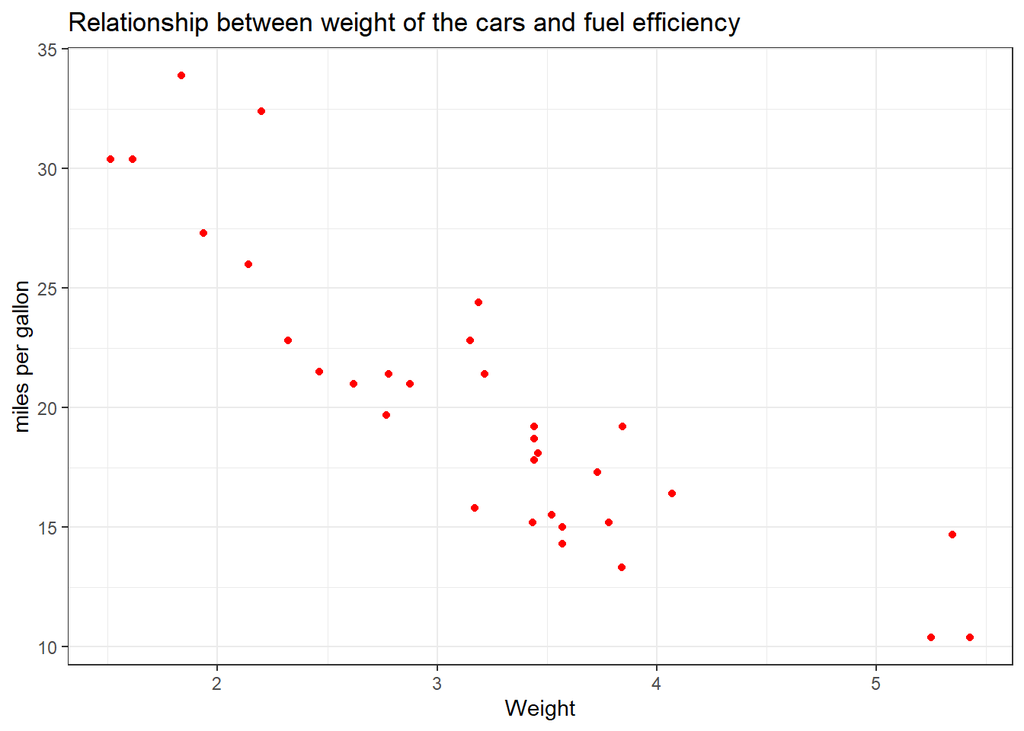

```r
library(tidyverse)
mtcars%>%
  ggplot(aes(wt,mpg))+
  geom_point(color="red")+
  labs(title="Relationship between weight of the cars and fuel efficiency",
       x="Weight",y="miles per gallon")+
  theme_bw()
```

Interpretation;

The graph suggests a negative relationship between weight and fuel efficiency. As the weight of a car increases, its miles per gallon (mpg) generally decrease. This indicates that heavier cars are less fuel-efficient than lighter cars.

## Question 2

Does horsepower affect fuel efficiency?

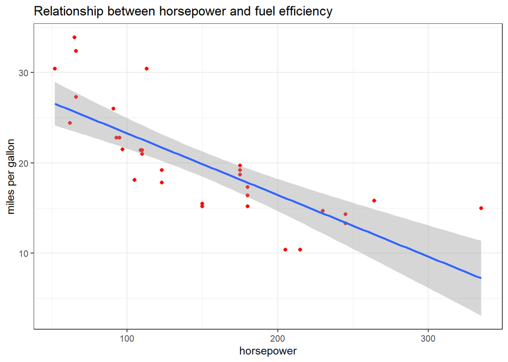

```r
mtcars%>%
  ggplot(aes(hp,mpg))+
  geom_point(color="red")+
  geom_smooth(method="lm",se=T)+
  labs(title="Relationship between horsepower and fuel efficiency",x=
         "horsepower",y="miles per gallon")+
  theme_bw()
```

Interpretation

The graph shows a strong negative relationship between horsepower and fuel efficiency. As horsepower increases, miles per gallon (MPG) clearly decreases. In other words, more powerful cars tend to be less fuel-efficient.

## Question 3

### Do manual cars have better fuel efficiency than automatic cars?

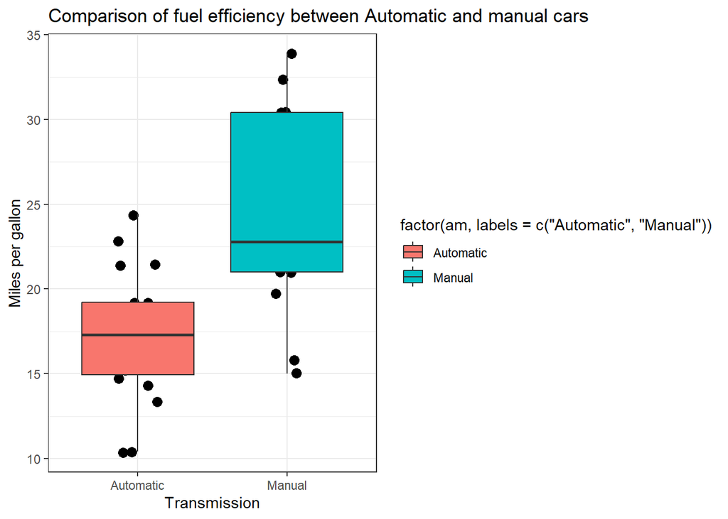

```r
mtcars%>%
  ggplot(aes(factor(am,labels=c("Automatic","Manual")),mpg,fill=factor(am,labels=c("Automatic","Manual"))))+
  geom_jitter(width = 0.15, size = 3)+
  geom_boxplot()+
  labs(title="Comparison of fuel efficiency between Automatic and manual cars",x="Transmission",y="Miles per gallon")+
  theme_bw()
```

Interpretation

Manual transmission cars generally have a higher median fuel efficiency than automatic transmission cars.

## Question 4

Which cylinder category has the highest average horsepower?

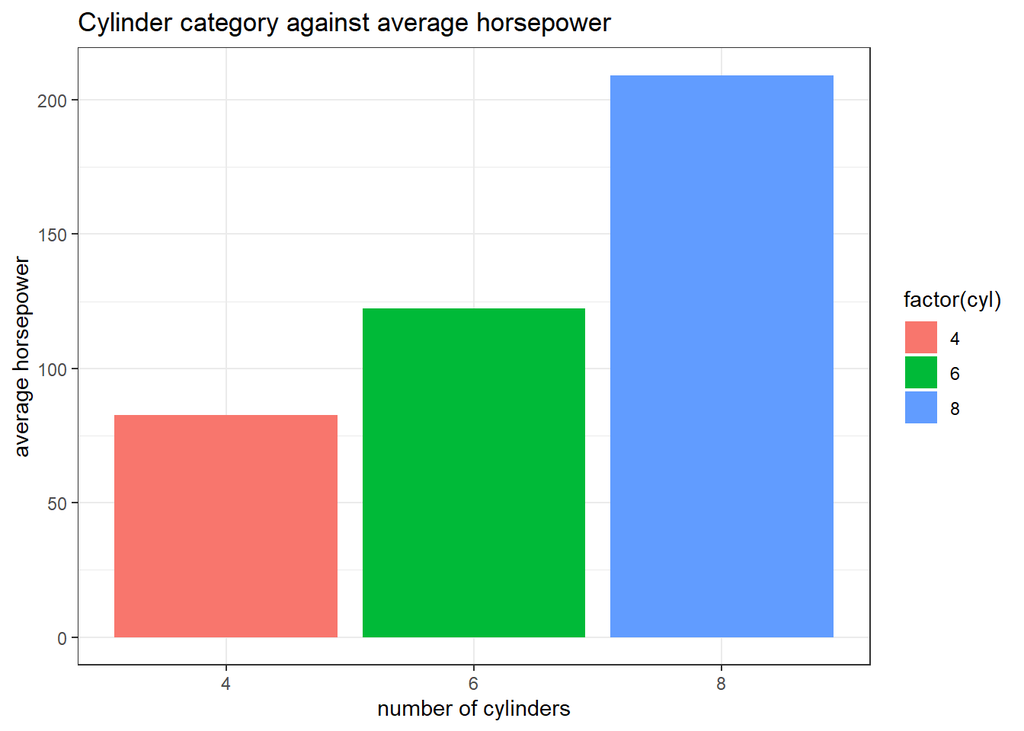

```r
mtcars%>%
  group_by(cyl)%>%
  summarise(avg_hp=mean(hp))%>%
  ggplot(aes(factor(cyl),avg_hp,fill=factor(cyl)))+
  geom_col()+
  labs(title="Cylinder category against average horsepower",y="average horsepower",x="number of cylinders")+
  theme_bw()
```

Interpretation

The bar chart shows that 8-cylinder cars have the highest average horsepower, followed by 6-cylinder cars, while 4-cylinder cars have the lowest average horsepower. This indicates that vehicles with a greater number of cylinders generally produce more engine power.

## Question 5

Which transmission type is more common?

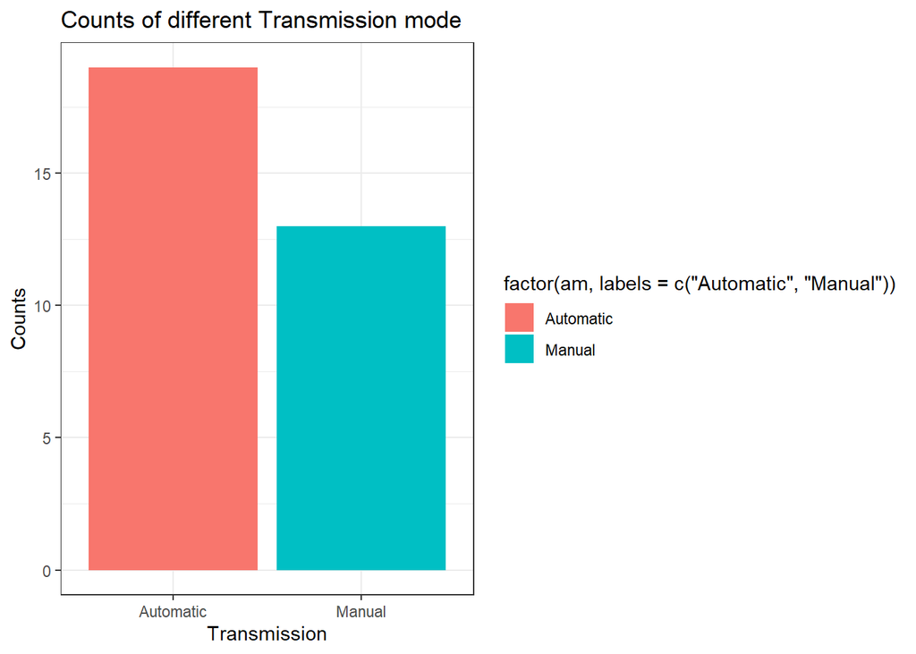

```r
mtcars%>%
  ggplot(aes(factor(am,labels=c("Automatic","Manual")),fill=factor(am,labels=c("Automatic","Manual"))))+
  geom_bar()+
  labs(title="Counts of different Transmission mode",y="Counts",x="Transmission")+
  theme_bw()
```

Interpretation

The bar chart shows that automatic transmission cars are more common in the dataset than manual transmission cars.

## Question 6

How are cars distributed according to fuel efficiency?

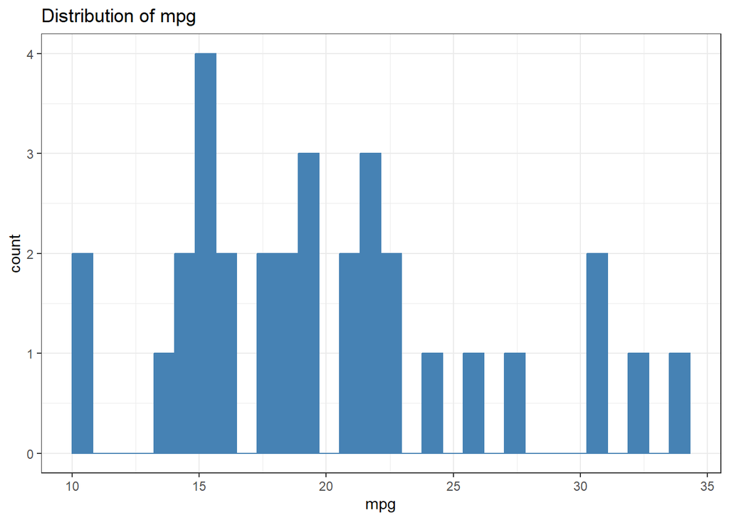

```r
mtcars%>%
  ggplot(aes(mpg))+
  geom_histogram(fill="steelblue",color="steelblue")+
  labs(title="Distribution of mpg")+
  theme_bw()
```

Interpretation

The histogram shows that most cars in the dataset have fuel efficiency between approximately 15 and 22 miles per gallon. Only a few cars have extremely low fuel efficiency (around 10 mpg) or very high fuel efficiency (above 30 mpg). Overall, the distribution indicates that moderate fuel efficiency is more common than extremely low or high fuel efficiency among the cars in the dataset.

## Question 7

Is horsepower related to vehicle weight?

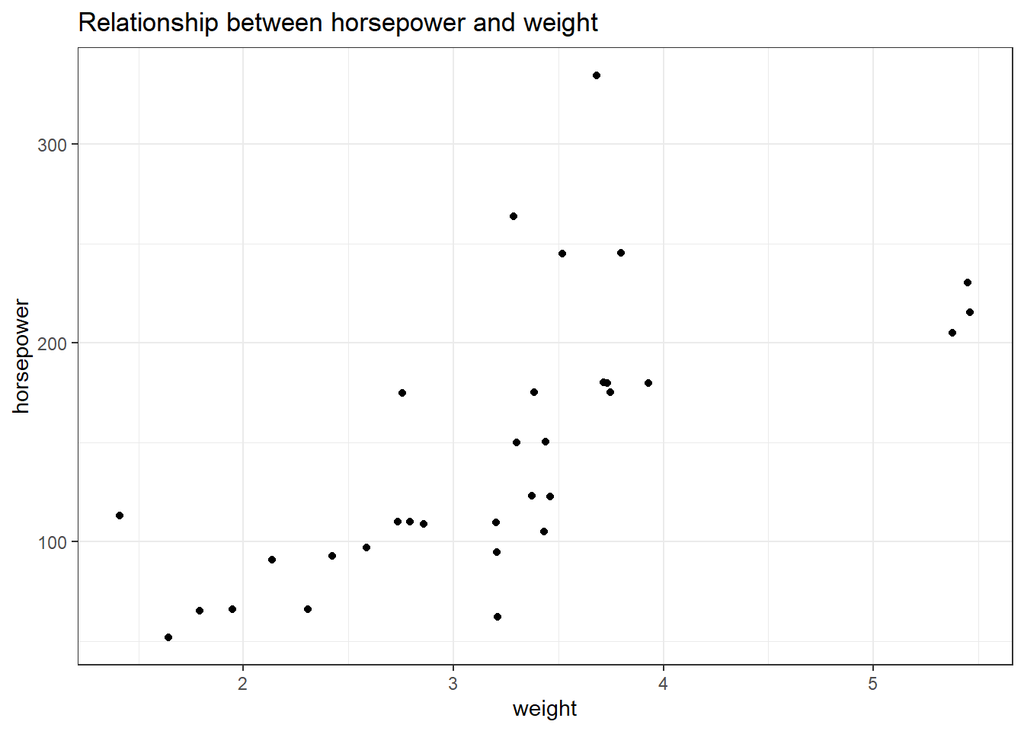

```r
mtcars%>%
  ggplot(aes(wt,hp))+
  geom_jitter(width=0.15)+
  labs(title="Relationship between horsepower and weight",y="horsepower",x="weight")+
  theme_bw()
```

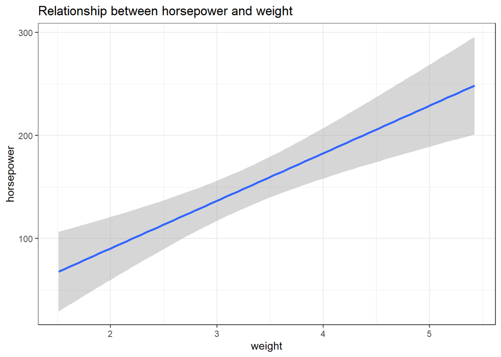

```r
mtcars%>%
  ggplot(aes(wt,hp))+
  geom_smooth(method="lm")+
  labs(title="Relationship between horsepower and weight",y="horsepower",x="weight")+
  theme_bw()
```

Interpretation

The scatter plot indicates a moderate positive relationship between vehicle weight and horsepower. In general, heavier vehicles tend to have higher horsepower than lighter vehicles. However, the relationship is not perfect, as vehicles with similar weights can have noticeably different horsepower values. This suggests that while weight is associated with horsepower, other vehicle characteristics also contribute to engine power. The plot also contains a possible outlier with exceptionally high horsepower compared with other vehicles of similar weight.

The fitted regression line indicates a positive linear relationship between vehicle weight and horsepower. On average, heavier vehicles tend to have higher horsepower.

## Question 8

Does fuel efficiency differ by the number of cylinders?

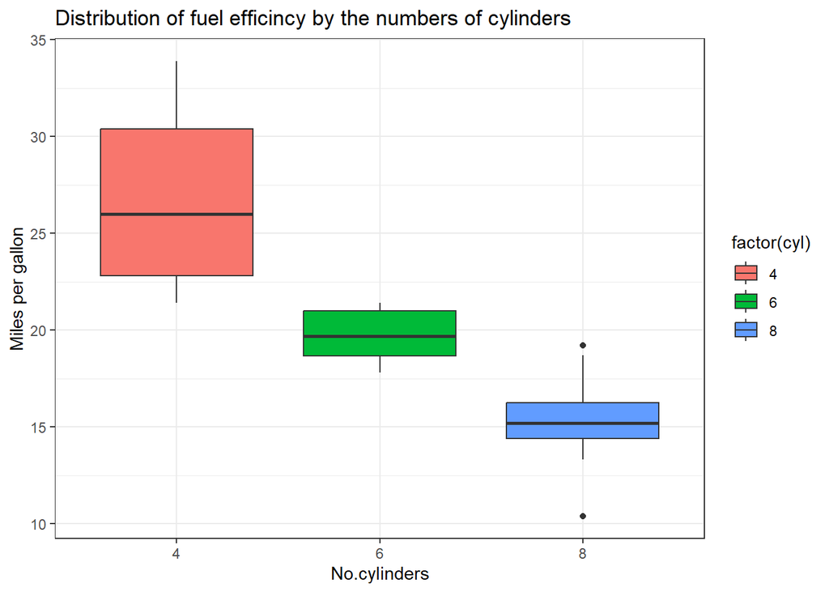

```r
mtcars%>%
  ggplot(aes(factor(cyl),mpg,fill=factor(cyl)))+
  geom_boxplot()+
  labs(title="Distribution of fuel efficincy by the numbers of cylinders ",x="No.cylinders",y="Miles per gallon")+
  theme_bw()
```

Interpretation

The boxplot shows that fuel efficiency varies across cylinder categories. Cars with four cylinders have the highest median fuel efficiency, followed by six-cylinder cars, while eight-cylinder cars have the lowest median fuel efficiency. This suggests that vehicles with fewer cylinders are generally more fuel-efficient. The four-cylinder group also exhibits greater variability in fuel efficiency compared with the six- and eight-cylinder groups. Additionally, the eight-cylinder category contains a few outliers, indicating unusually high or low fuel efficiency relative to other vehicles in the same group.

## Question 9

Correlation Matrix

```r
cor(mtcars)
```

```
            mpg        cyl       disp         hp        drat         wt
mpg   1.0000000 -0.8521620 -0.8475514 -0.7761684  0.68117191 -0.8676594
cyl  -0.8521620  1.0000000  0.9020329  0.8324475 -0.69993811  0.7824958
disp -0.8475514  0.9020329  1.0000000  0.7909486 -0.71021393  0.8879799
hp   -0.7761684  0.8324475  0.7909486  1.0000000 -0.44875912  0.6587479
drat  0.6811719 -0.6999381 -0.7102139 -0.4487591  1.00000000 -0.7124406
wt   -0.8676594  0.7824958  0.8879799  0.6587479 -0.71244065  1.0000000
qsec  0.4186840 -0.5912421 -0.4336979 -0.7082234  0.09120476 -0.1747159
vs    0.6640389 -0.8108118 -0.7104159 -0.7230967  0.44027846 -0.5549157
am    0.5998324 -0.5226070 -0.5912270 -0.2432043  0.71271113 -0.6924953
gear  0.4802848 -0.4926866 -0.5555692 -0.1257043  0.69961013 -0.5832870
carb -0.5509251  0.5269883  0.3949769  0.7498125 -0.09078980  0.4276059
            qsec         vs          am       gear        carb
mpg   0.41868403  0.6640389  0.59983243  0.4802848 -0.55092507
cyl  -0.59124207 -0.8108118 -0.52260705 -0.4926866  0.52698829
disp -0.43369788 -0.7104159 -0.59122704 -0.5555692  0.39497686
hp   -0.70822339 -0.7230967 -0.24320426 -0.1257043  0.74981247
drat  0.09120476  0.4402785  0.71271113  0.6996101 -0.09078980
wt   -0.17471588 -0.5549157 -0.69249526 -0.5832870  0.42760594
qsec  1.00000000  0.7445354 -0.22986086 -0.2126822 -0.65624923
vs    0.74453544  1.0000000  0.16834512  0.2060233 -0.56960714
am   -0.22986086  0.1683451  1.00000000  0.7940588  0.05753435
gear -0.21268223  0.2060233  0.79405876  1.0000000  0.27407284
carb -0.65624923 -0.5696071  0.05753435  0.2740728  1.00000000
```

Interpretation

The correlation matrix revealed several strong relationships among the numerical variables. Vehicle weight was strongly negatively correlated with fuel efficiency (r = -0.868), indicating that heavier cars tend to consume more fuel. Engine displacement showed a strong positive correlation with the number of cylinders (r = 0.902) and vehicle weight (r = 0.888), suggesting that larger engines are generally found in heavier vehicles. Horsepower was also strongly negatively correlated with fuel efficiency (r = -0.776), indicating that more powerful cars tend to achieve lower miles per gallon.

# Summary

This exploratory data analysis examined the relationships between selected vehicle characteristics in the **mtcars** dataset. The analysis revealed that **vehicle weight and horsepower are negatively associated with fuel efficiency**, indicating that heavier and more powerful cars generally achieve lower miles per gallon (MPG). The comparison of transmission types showed that **manual transmission cars tend to have higher fuel efficiency than automatic cars**. Additionally, the analysis of cylinder categories demonstrated that **vehicles with more cylinders have higher average horsepower**, suggesting that engine power generally increases with the number of cylinders.

# Skills demonstrated

✔ Data exploration

✔ Data cleaning

✔ Data manipulation using dplyr

✔ Data visualization using ggplot2

✔ Statistical interpretation

✔ Group summaries

✔ Professional reporting using R Markdown